# Figure 2 mock-up: ensembles vs. single maps

Published

October 2, 2026

A backcast on a synthetic 90 × 90 landscape; the map panels show a 30 × 30 window of it. Domain and classes follow the evoland-plus vignette `stochastic-allocation-sensitivity.qmd`; unlike the vignette, the initial map is structured (urban clustered where accessible, forest on better sites) and change between periods follows a known process driven by two latent drivers and the neighbourhood, so that there is something to learn. Calibrate on the transition from period 1 to 2, allocate period 3 from the observed period 2 `n_realisations` times with CLUMPY, and validate every realisation against the observed period 3, which calibration never sees.

Keeping the backcast honest:

- Periods 1 and 2 are observed, period 3 is flagged as extrapolated. Model fitting and allocation-parameter estimation therefore only see the transition 1 -> 2.
- The observed period 3 sits in a run of its own (`id_run_observed`), a child of the base run. The ensemble runs are siblings of it and cannot read it; the figure-of-merit view reads it as the reference.
- The demand for period 3 is the observed quantity of each transition from 2 to 3, as in the comparison protocol: the figure is about *where* change is placed, not how much.

Why 90 × 90 and this learner: `010-skill-attribution.r` showed that the allocator passes the potentials through unchanged, so a weak figure was weak estimation. `010-learner-comparison.r` found that ranger with default leaves on 30 × 30 reaches about a third of the skill the true probabilities attain. Ranger with larger leaves (`min.node.size = 50`) on all available predictors at 90 × 90 reaches about 83 %. Logistic regression does better still, but the synthetic process is logistic, which would give it home advantage.

```r
set.seed(1337)
library(evoland)
library(data.table)
library(terra)
library(ggplot2)
library(patchwork)
library(mlr3learners)

out_dir <- "2026-09-paper-figures/figures"
db_path <- "2026-09-paper-figures/fig2-ensembles.evolanddb"
unlink(db_path, recursive = TRUE)

n_realisations <- 100L
n_grid <- 90L # domain, cells per side
n_window <- 30L # map panels, cells per side
id_run_observed <- 1000L
```

# 1 Database, domain and synthetic landscape

```r
db <- evoland_db$new(path = db_path)

db$lulc_meta_t <- create_lulc_meta_t(list(
  forest = list(pretty_name = "Forest"),
  arable = list(pretty_name = "Arable Land"),
  urban = list(pretty_name = "Urban Areas"),
  static = list(pretty_name = "Immutable")
))

template_rast <- terra::rast(
  crs = "EPSG:2056",
  extent = terra::ext(c(
    xmin = 2697000,
    xmax = 2697000 + n_grid * 100,
    ymin = 1252000,
    ymax = 1252000 + n_grid * 100
  )),
  resolution = 100
)

db$coords_t <- create_coords_t_square(
  epsg = 2056L,
  extent = terra::ext(template_rast),
  resolution = terra::res(template_rast)[1]
)

# periods 1, 2 observed; period 3 held out as "extrapolated"
db$periods_t <- create_periods_t(
  period_length_str = "P10Y",
  start_observed = "2000-01-01",
  end_observed = "2010-01-01",
  end_extrapolated = "2020-01-01"
)
db$periods_t
```

```
Periods Table
Date range: [2000-01-01, 2029-12-31]
Observed periods: 3, Extrapolated periods: 1
Key: <start_date, end_date>
Index: <is_extrapolated>
   id_period start_date   end_date  mean_date period_length_d is_extrapolated
       <int>     <Date>     <Date>     <Date>           <int>          <lgcl>
1:         1 2000-01-01 2009-12-31 2004-12-31              NA           FALSE
2:         0 2010-01-01 2010-01-01 2010-01-01              NA           FALSE
3:         2 2010-01-01 2019-12-31 2015-01-01            3653           FALSE
4:         3 2020-01-01 2029-12-31 2024-12-31            3652            TRUE
```

## 1.1 Synthetic process

Two latent drivers, a nuisance field, and four transitions whose per-period probabilities depend on the drivers and the 5 × 5 neighbourhood; defined in `000-synthetic-process.r`, which the skill-attribution and learner-comparison steps share.

| transition | logit of the per-period probability |
| --- | --- |
| arable -> urban | −5.5 + 7 * share_urban + 3 * accessibility |
| forest -> urban | −7 + 6 * share_urban + 3 * accessibility |
| forest -> arable | −5 + 4 * (1 − site_quality) + 3 * share_arable |
| arable -> forest | −6 + 4 * site_quality * (1 − accessibility) + 3 * share_forest |

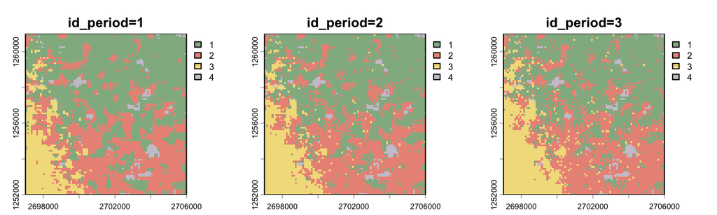

```r
options(synthetic_process.source_only = TRUE)
source("2026-09-paper-figures/000-synthetic-process.r")

drivers <- make_drivers(template_rast)
accessibility <- drivers$accessibility
site_quality <- drivers$site_quality
random_nuisance <- drivers$random_nuisance

initial <- make_landscape(template_rast, drivers)
lulc_2 <- step_process(initial, drivers)
lulc_3 <- step_process(lulc_2, drivers)
synthetic_lulc <- c(initial, lulc_2, lulc_3) |>
  setNames(paste0("id_period=", 1:3))

plot(
  synthetic_lulc,
  nc = 3,
  col = data.frame(
    value = 1:4,
    color = c("#91B690", "#EB9486", "#F3DE8A", "#CBC6D2")
  )
)
```

```r
lulc_long <- extract_using_coords_t(synthetic_lulc, db$coords_t)[,
  .(
    id_coord,
    id_period = as.integer(sub(".*[^0-9]", "", layer)),
    id_lulc = value
  )
]
lulc_long[, .N, by = .(id_period, id_lulc)][order(id_period, id_lulc)]
```

```
    id_period id_lulc     N
        <int>   <num> <int>
 1:         1       1  4112
 2:         1       2  2787
 3:         1       3   972
 4:         1       4   229
 5:         2       1  3877
 6:         2       2  2810
 7:         2       3  1184
 8:         2       4   229
 9:         3       1  3607
10:         3       2  2857
11:         3       3  1407
12:         3       4   229
```

```r
db$lulc_data_t <- as_lulc_data_t(lulc_long[
  id_period <= 2L,
  .(id_run = 0L, id_coord, id_period, id_lulc)
])
```

# 2 Predictors

The model sees the two drivers, a nuisance field, and evoland’s neighbourhood predictors (computed from the land use map), but not the functional form above.

```r
db$pred_meta_t <- create_pred_meta_t(list(
  accessibility = list(description = "synthetic driver", data_type = "float"),
  site_quality = list(description = "synthetic driver", data_type = "float"),
  random_nuisance = list(
    description = "synthetic nuisance",
    data_type = "float"
  )
))

db$pred_data_t <- extract_using_coords_t(
  c(accessibility, site_quality, random_nuisance) |>
    setNames(c("accessibility", "site_quality", "random_nuisance")),
  db$coords_minimal
)[, layer := as.character(layer)][,
  .(
    id_coord,
    id_run = 0L,
    id_period = 0L,
    id_pred = fcase(
      layer == "accessibility"   ,
      1L                         ,
      layer == "site_quality"    ,
      2L                         ,
      layer == "random_nuisance" ,
      3L
    ),
    value
  )
] |>
  as_pred_data_t()

db$set_neighbors(
  max_distance = 1000,
  distance_breaks = c(0, 300, 1000),
  quiet = TRUE
)
```

```
Computed 2321080 neighbor relationships
```

```r
db$generate_neighbor_predictors()
```

```
Appended 8 neighbor predictor variables with 88023 data points
```

# 3 Calibration on 1 -> 2

```r
db$trans_meta_t <- create_trans_meta_t(
  db$trans_v,
  min_cardinality_abs = 10,
  exclude_anterior = 4
)
# all available predictors: in 010-learner-comparison, preselecting rpart's top 4 cost ranger skill
db$set_full_trans_preds()
```

```
[1] 44
```

```r
# larger leaves give better-calibrated probabilities (010-learner-comparison)
trans_models <- db$fit_full_models(
  learner = mlr3::lrn("classif.ranger", num.trees = 500, min.node.size = 50)
)
```

```
Fitting full models for 4 transitions...
```

```r
modeled_trans <- unique(trans_models$id_trans[
  !vapply(trans_models$learner_full, is.null, logical(1L))
])
db$trans_models_t <- trans_models
trans_meta <- db$trans_meta_t
trans_meta[, is_viable := is_viable & id_trans %in% modeled_trans]
db$trans_meta_t <- trans_meta

alloc_params_estimated <- db$create_alloc_params_t()
```

```
Computing allocation parameters for 4 transitions across 1 periods...
```

```
  Processing period 1 -> 2
```

```
Aggregating parameters across periods...
```

```
Computed allocation parameters for 4 transitions (id_run=0)
```

```r
alloc_params_estimated
# The synthetic process changes cells independently, so single-cell allocation (uSAM) is the
# allocator that matches it. The estimated "patches" (mean 1.1-1.2 cells) are clusters induced
# by the neighbourhood terms of the process. Allocating with them (uPAM) moves change onto
# less probable neighbours: the logistic-regression ensemble then puts 28 % of its change in
# the top 5 % of true probabilities instead of the 36 % a sampler of the truth puts there.
db$alloc_params_t <- as_alloc_params_t(
  copy(alloc_params_estimated)[, `:=`(mean_patch_size = 1, patch_size_variance = 0)][]
)
db$trans_meta_t[is_viable == TRUE]
```

[output not shown]

```
Transition Metadata Table
Total transition types: 4
Viable for modelling: 4
Total observed transitions: 547
Key: <id_lulc_anterior, id_lulc_posterior>
   id_trans id_lulc_anterior id_lulc_posterior cardinality frequency_rel
      <int>            <int>             <int>       <int>         <num>
1:        1                1                 2         265    0.48446069
2:        2                1                 3          40    0.07312614
3:        3                2                 1          70    0.12797075
4:        4                2                 3         172    0.31444241
   frequency_abs is_viable
           <num>    <lgcl>
1:   0.032716049      TRUE
2:   0.004938272      TRUE
3:   0.008641975      TRUE
4:   0.021234568      TRUE
```

# 4 Demand: observed quantities 2 -> 3

```r
observed_2_3 <- lulc_long[
  id_period == 2L,
  .(id_coord, id_lulc_anterior = id_lulc)
][
  lulc_long[id_period == 3L, .(id_coord, id_lulc_posterior = id_lulc)],
  on = "id_coord"
]
anterior_totals <- observed_2_3[, .(n_anterior = .N), by = id_lulc_anterior]
observed_counts <- observed_2_3[
  id_lulc_anterior != id_lulc_posterior,
  .(count = .N),
  by = .(id_lulc_anterior, id_lulc_posterior)
]

rates_3 <- db$trans_meta_t[
  is_viable == TRUE,
  .(id_trans, id_lulc_anterior, id_lulc_posterior)
][observed_counts, on = .(id_lulc_anterior, id_lulc_posterior), nomatch = NULL][
  anterior_totals,
  on = "id_lulc_anterior",
  nomatch = NULL
][, .(id_run = 0L, id_period = 3L, id_trans, count, rate = count / n_anterior)]
db$trans_rates_t <- as_trans_rates_t(rates_3)

# change the model cannot produce: transitions not viable after 1 -> 2
unmodelled_change <- observed_counts[, sum(count)] - rates_3[, sum(count)]
rates_3
```

```
Transition Rates Table
Periods covered: 1
Transition types: 4
Rate range: [0.0083, 0.0758]
Key: <id_run, id_period, id_trans>
   id_run id_period id_trans count        rate
    <int>     <int>    <int> <int>       <num>
1:      0         3        1   294 0.075831829
2:      0         3        2    32 0.008253804
3:      0         3        3    56 0.019928826
4:      0         3        4   191 0.067971530
```

```r
unmodelled_change
```

```
[1] 0
```

# 5 Runs: the held-out observation and one ensemble per learner

Two estimators produce potentials for the same allocator. The random forest (calibrated above, run 0) is the general-purpose choice; the logistic regression is correctly specified for this synthetic process, whose transition probabilities are logistic in the drivers and neighbourhood shares. It therefore shows what the allocation does when the potentials are close to the truth. Each learner’s ensemble sits below its own parent run, so its members inherit that learner’s potentials and nothing else.

```r
learners <- data.table(
  learner = c("ranger", "log_reg"),
  label = c("random forest", "logistic regression"),
  id_run_parent = c(0L, 2000L)
)
members <- learners[,
  .(id_run = id_run_parent + seq_len(n_realisations), member = seq_len(n_realisations)),
  by = .(learner, label, id_run_parent)
][, seed := 1000L + .I]

runs <- rbind(
  data.table(
    id_run = c(0L, id_run_observed, 2000L),
    parent_id_run = c(NA_integer_, 0L, 0L),
    description = c(
      "calibration base, random forest potentials",
      "observed period 3 (validation only)",
      "logistic regression potentials"
    ),
    seed = NA_integer_
  ),
  members[, .(
    id_run,
    parent_id_run = id_run_parent,
    description = paste(label, "realisation", member),
    seed
  )]
)
db$commit(as_runs_t(runs), "runs_t", method = "overwrite")
```

```
[1] 203
```

```r
db$lulc_data_t <- as_lulc_data_t(lulc_long[
  id_period == 3L,
  .(id_run = id_run_observed, id_coord, id_period, id_lulc)
])
```

The logistic regression is fitted on the same predictors, under its own run. Its potentials are predicted with `force = TRUE`: otherwise the lineage read would find run 0’s potentials and reuse them.

```r
db$id_run <- 2000L
log_reg_models <- db$fit_full_models(
  learner = mlr3::lrn("classif.log_reg"),
  trans_preds = as_trans_preds_t(db$trans_preds_t[, .(id_run = 2000L, id_pred, id_trans)])
)
```

```
Fitting full models for 4 transitions...
```

```r
db$trans_models_t <- log_reg_models
db$predict_trans_pot(
  id_period_post = 3L,
  select_score = "no.crossval",
  select_maximize = TRUE,
  force = TRUE
)
```

[output not shown]

```
Predicting transition 1/4 (id_trans=1)
```

```
Predicting transition 2/4 (id_trans=2)
```

```
Predicting transition 3/4 (id_trans=3)
```

```
Predicting transition 4/4 (id_trans=4)
```

```r
for (i in seq_len(nrow(members))) {
  db$id_run <- members$id_run[i]
  set.seed(members$seed[i])
  db$alloc_clumpy(
    id_periods = 3,
    select_score = "no.crossval",
    select_maximize = TRUE,
    use_parent_trans_pot = TRUE,
    update_neighbors = FALSE
  )
}
```

# 6 A deterministic comparator on the same potentials

Tools without stochastic allocation return one map. As a stand-in until the real comparators run (`2026-09-model-comparison/`), allocate the same demand deterministically on each learner’s adjusted potentials: greedily, highest potential first, one class per cell. This isolates the allocator’s contribution; it says nothing about how Dinamica or LCM would score.

```r
adjusted_by <- lapply(setNames(learners$id_run_parent, learners$learner), function(id) {
  db$id_run <- id
  db$adjusted_trans_pot_v(3L)
})

greedy_map <- function(adjusted) {
  candidates <- adjusted[, .(id_coord, id_trans, potential = value)][
    db$trans_meta_t[, .(id_trans, id_lulc_posterior)],
    on = "id_trans",
    nomatch = NULL
  ][rates_3[, .(id_trans, quota = count)], on = "id_trans", nomatch = NULL][
    order(-potential)
  ]
  remaining <- setNames(
    candidates[, quota[1], by = id_trans]$V1,
    candidates[, unique(id_trans)]
  )
  assigned <- new.env()
  keep <- logical(nrow(candidates))
  for (i in seq_len(nrow(candidates))) {
    key <- as.character(candidates$id_coord[i])
    tr <- as.character(candidates$id_trans[i])
    if (remaining[[tr]] > 0 && is.null(assigned[[key]])) {
      assigned[[key]] <- TRUE
      remaining[[tr]] <- remaining[[tr]] - 1L
      keep[i] <- TRUE
    }
  }
  out <- lulc_long[id_period == 2L, .(id_coord, deterministic = id_lulc)]
  out[
    candidates[keep, .(id_coord, id_lulc_posterior)],
    on = "id_coord",
    deterministic := i.id_lulc_posterior
  ]
  out[]
}
deterministic_by <- lapply(adjusted_by, greedy_map)
```

# 7 Validation

```r
db$id_run <- NULL
fom <- db$figure_of_merit_v(
  id_period_anterior = 2L,
  id_period_post = 3L,
  id_run_reference = id_run_observed,
  id_run_simulated = members$id_run
)[members[, .(id_run, learner, label)], on = "id_run"]

# expected counts of each ensemble: ratio of mean counts, not mean of ratios
fom_ensemble <- fom[,
  lapply(.SD, mean),
  by = .(learner, label),
  .SDcols = c("hits", "wrong_hits", "misses", "false_alarms")
][, figure_of_merit := hits / (hits + wrong_hits + misses + false_alarms)]

fom_counts <- function(anterior, observed, simulated) {
  obs_change <- anterior != observed
  sim_change <- anterior != simulated
  hits <- sum(obs_change & sim_change & simulated == observed)
  wrong <- sum(obs_change & sim_change & simulated != observed)
  misses <- sum(obs_change & !sim_change)
  false_alarms <- sum(!obs_change & sim_change)
  hits / (hits + wrong + misses + false_alarms)
}
maps <- lulc_long[id_period == 2L, .(id_coord, anterior = id_lulc)][
  lulc_long[id_period == 3L, .(id_coord, observed = id_lulc)],
  on = "id_coord"
]
fom_deterministic <- learners[, .(
  learner,
  label,
  figure_of_merit = vapply(
    learner,
    function(lr) {
      maps[deterministic_by[[lr]], on = "id_coord"][,
        fom_counts(anterior, observed, deterministic)
      ]
    },
    numeric(1L)
  )
)]
fom_null <- mean(fom$figure_of_merit_null)

simulated_all <- db$fetch(
  "lulc_data_t",
  where = glue::glue(
    "id_run in ({paste(members$id_run, collapse = ', ')}) and id_period = 3"
  )
)[, .(id_run, id_coord, simulated = id_lulc)][members[, .(id_run, learner)], on = "id_run"]

knitr::kable(
  fom[,
    .(
      fom_median = median(figure_of_merit),
      fom_q05 = quantile(figure_of_merit, 0.05),
      fom_q95 = quantile(figure_of_merit, 0.95)
    ),
    by = .(learner)
  ][fom_ensemble[, .(learner, fom_ensemble = figure_of_merit)], on = "learner"][
    fom_deterministic[, .(learner, fom_deterministic = figure_of_merit)],
    on = "learner"
  ][, fom_random_null := fom_null][],
  digits = 3
)
```

| learner | fom_median | fom_q05 | fom_q95 | fom_ensemble | fom_deterministic | fom_random_null |
| --- | --- | --- | --- | --- | --- | --- |
| ranger | 0.133 | 0.118 | 0.149 | 0.134 | 0.240 | 0.033 |
| log_reg | 0.151 | 0.139 | 0.162 | 0.150 | 0.257 | 0.033 |

# 8 Probabilistic scores: which class, not just whether

The multiclass Brier score (Brier, 1950) scores the full outcome: for each cell, the sum over posterior classes k of (p_k - o_k)^2, where o is the observed class as a one-hot vector. It ranges from 0 to 2. A hard map scores 0 on a correct cell and 2 on any miss, false alarm or wrong hit. Scores are averaged over the cells that can change.

Forecasts compared, per learner: the ensemble frequency (with the fair correction for a finite ensemble, Ferro 2014), the adjusted potentials the allocator samples from, the deterministic map and single realisations. References: the true probabilities, climatology (every cell of an anterior class gets that class’s demand rates; the reference for the skill score BSS = 1 - BS / BS_climatology) and persistence.

```r
cell_of <- data.table(
  id_coord = db$coords_minimal$id_coord,
  cell = terra::cellFromXY(template_rast, as.matrix(db$coords_minimal[, .(lon, lat)]))
)
truth <- true_probs(lulc_2, drivers)[cell_of, on = "cell", nomatch = NULL]
```

```r
viable <- db$trans_meta_t[
  is_viable == TRUE,
  .(id_trans, id_lulc_anterior, id_lulc_posterior)
]
classes <- sort(unique(c(maps$anterior, maps$observed)))
eligible <- maps[anterior %in% viable$id_lulc_anterior, id_coord]
anterior_of <- maps[id_coord %in% eligible, .(id_coord, anterior)]

# a forecast is a long table (id_coord, class, p); classes it omits get p = 0
complete_p <- function(f) {
  f <- f[id_coord %in% eligible, .(p = sum(p)), by = .(id_coord, class)]
  f[CJ(id_coord = eligible, class = classes), on = .(id_coord, class)][
    is.na(p),
    p := 0
  ][]
}
# transition probabilities per cell, with persistence as the remainder
persist <- function(trans_p) {
  stay <- trans_p[, .(leave = sum(p)), by = id_coord][
    anterior_of,
    on = "id_coord"
  ][is.na(leave), leave := 0][, .(id_coord, class = anterior, p = 1 - leave)]
  rbind(trans_p[, .(id_coord, class, p)], stay)
}
observed_p <- complete_p(maps[, .(id_coord, class = observed, p = 1)])[,
  .(id_coord, class, o = p)
]
brier <- function(f, n_members = NA_integer_) {
  d <- complete_p(f)[observed_p, on = .(id_coord, class)]
  cell <- d[,
    .(
      multi = sum((p - o)^2),
      noise = if (is.na(n_members)) 0 else sum(p * (1 - p)) / (n_members - 1)
    ),
    by = id_coord
  ]
  cell[, mean(multi - noise)]
}
potentials_long <- function(adjusted) {
  adjusted[viable, on = "id_trans", nomatch = NULL][,
    .(id_coord, class = id_lulc_posterior, p = value)
  ]
}

scores <- rbindlist(c(
  lapply(learners$learner, function(lr) {
    sims <- simulated_all[learner == lr]
    draws <- sims[, .(bs = brier(.SD[, .(id_coord, class = simulated, p = 1)])), by = id_run]
    data.table(
      learner = lr,
      forecast = c(
        "ensemble frequency (fair)",
        "adjusted potentials",
        "deterministic",
        "single realisation (median)"
      ),
      brier = c(
        brier(
          sims[, .(p = .N / n_realisations), by = .(id_coord, class = simulated)],
          n_realisations
        ),
        brier(persist(potentials_long(adjusted_by[[lr]]))),
        brier(deterministic_by[[lr]][, .(id_coord, class = deterministic, p = 1)]),
        median(draws$bs)
      )
    )
  }),
  list(data.table(
    learner = "reference",
    forecast = c("true probabilities", "climatology", "persistence"),
    brier = c(
      brier(persist(truth[, .(id_coord, class, p = q)])),
      brier(persist(
        anterior_of[
          viable[rates_3[, .(id_trans, rate)], on = "id_trans", nomatch = NULL],
          on = c(anterior = "id_lulc_anterior"),
          allow.cartesian = TRUE,
          nomatch = NULL
        ][, .(id_coord, class = id_lulc_posterior, p = rate)]
      )),
      brier(maps[, .(id_coord, class = anterior, p = 1)])
    )
  ))
))
scores[, skill := 1 - brier / scores[forecast == "climatology", brier]]
knitr::kable(scores, digits = 4)
```

| learner | forecast | brier | skill |
| --- | --- | --- | --- |
| ranger | ensemble frequency (fair) | 0.1327 | 0.1630 |
| ranger | adjusted potentials | 0.1336 | 0.1576 |
| ranger | deterministic | 0.2082 | -0.3129 |
| ranger | single realisation (median) | 0.2578 | -0.6261 |
| log_reg | ensemble frequency (fair) | 0.1293 | 0.1843 |
| log_reg | adjusted potentials | 0.1295 | 0.1831 |
| log_reg | deterministic | 0.2010 | -0.2677 |
| log_reg | single realisation (median) | 0.2505 | -0.5799 |
| reference | true probabilities | 0.1282 | 0.1913 |
| reference | climatology | 0.1585 | 0.0000 |
| reference | persistence | 0.1714 | -0.0809 |

# 9 Where change is placed: the bias of a deterministic map

The deterministic map wins on FoM by putting all change on the highest potentials. Observed change does not behave like that: it also happens on cells of moderate probability, in proportion to that probability. For every changed cell, take the percentile of its *true* transition probability among all cells that could make the same transition. The truth is the same for both learners, and percentiles let transitions with different probability scales be pooled. Then compare the distributions of those percentiles for the observed change, the realisations and the greedy maps. Random allocation would give a uniform distribution (the diagonal).

An unbiased sampler of the true probabilities reproduces the observed curve in expectation. The logistic-regression ensemble comes close to that because its potentials are nearly the truth here (the model is correctly specified); the random forest’s realisations deviate by as much as its potentials do.

```r
truth_rank <- truth[,
  .(id_coord, rank = frank(q, ties.method = "average") / .N),
  by = .(id_lulc_anterior, class)
]
rank_of_change <- function(changes) {
  truth_rank[
    changes,
    on = .(id_coord, id_lulc_anterior = anterior, class = posterior),
    nomatch = NULL
  ]
}
rank_grid <- seq(0, 1, by = 0.005)
ecdf_on_grid <- function(r) stats::ecdf(r)(rank_grid)

ranks_observed <- rank_of_change(
  maps[anterior != observed, .(id_coord, anterior, posterior = observed)]
)
ranks_deterministic <- rbindlist(
  lapply(learners$learner, function(lr) {
    maps[deterministic_by[[lr]], on = "id_coord"][
      anterior != deterministic,
      .(id_coord, anterior, posterior = deterministic)
    ] |>
      rank_of_change() |>
      cbind(learner = lr)
  })
)
ranks_draws <- rank_of_change(
  simulated_all[maps[, .(id_coord, anterior)], on = "id_coord"][
    anterior != simulated,
    .(id_run, learner, id_coord, anterior, posterior = simulated)
  ]
)

cdf_observed <- ecdf_on_grid(ranks_observed$rank)
cdf_draws <- ranks_draws[,
  .(x = rank_grid, cdf = ecdf_on_grid(rank)),
  by = .(learner, id_run)
]
cdf_band <- cdf_draws[,
  .(lo = quantile(cdf, 0.05), med = median(cdf), hi = quantile(cdf, 0.95)),
  by = .(learner, x)
]
cdf_deterministic <- ranks_deterministic[,
  .(x = rank_grid, cdf = ecdf_on_grid(rank)),
  by = learner
]

bias_tab <- rbind(
  data.table(
    changed_cells = "observed",
    learner = NA_character_,
    share_in_top_5_pct = mean(ranks_observed$rank > 0.95),
    median_percentile = median(ranks_observed$rank)
  ),
  ranks_draws[,
    .(share = mean(rank > 0.95), med = median(rank)),
    by = .(learner, id_run)
  ][,
    .(
      changed_cells = "realisations (median)",
      share_in_top_5_pct = median(share),
      median_percentile = median(med)
    ),
    by = learner
  ],
  ranks_deterministic[,
    .(
      changed_cells = "deterministic",
      share_in_top_5_pct = mean(rank > 0.95),
      median_percentile = median(rank)
    ),
    by = learner
  ],
  use.names = TRUE
)
knitr::kable(bias_tab, digits = 3)
```

| changed_cells | learner | share_in_top_5_pct | median_percentile |
| --- | --- | --- | --- |
| observed | NA | 0.361 | 0.909 |
| realisations (median) | ranger | 0.332 | 0.899 |
| realisations (median) | log_reg | 0.381 | 0.918 |
| deterministic | ranger | 0.649 | 0.965 |
| deterministic | log_reg | 0.731 | 0.970 |

```r
# Kolmogorov-Smirnov distance of each curve to the observed one. Not shown in the figure: the
# distance is not widely known, and the panel shows the bias plainly. Uncomment to report it.
# ks_draws <- cdf_draws[, .(ks = max(abs(cdf - cdf_observed))), by = .(learner, id_run)]
# ks_draws[, .(ks_median = median(ks)), by = learner]
# cdf_deterministic[, .(ks = max(abs(cdf - cdf_observed))), by = learner]
```

# 10 Figure

Six cells of a 3 x 2 grid: three maps on top, the FoM strip across two cells and the bias panel in the last one below. Map panels show one n_window x n_window block of the domain, the block with the most observed change; every score, panel (d) and panel (e) use the whole domain. Each panel keeps its own legend.

```r
# a plain data.table: a coords_t subset would carry the class and its print method
coords_xy <- data.table(
  id_coord = db$coords_t$id_coord,
  x = db$coords_t$lon,
  y = db$coords_t$lat
)
coords_xy[,
  block := paste(
    (x - min(x)) %/% (100 * n_window),
    (y - min(y)) %/% (100 * n_window)
  )
]
shown_block <- coords_xy[
  maps[anterior != observed, .(id_coord)],
  on = "id_coord"
][, .N, by = block][order(-N)][1, block]
coords_xy <- coords_xy[block == shown_block, .(id_coord, x, y)]

outcome <- function(anterior, observed, simulated) {
  obs_change <- anterior != observed
  sim_change <- anterior != simulated
  fcase(
    obs_change & sim_change & simulated == observed , "hit"         ,
    obs_change & sim_change                         , "wrong hit"   ,
    obs_change                                      , "miss"        ,
    sim_change                                      , "false alarm" ,
    default = "persistence"
  )
}

# the realisation shown: the random forest draw closest to its ensemble median
fom_ranger <- fom[learner == "ranger"]
shown_run <- fom_ranger[order(abs(figure_of_merit - median(figure_of_merit)))][1, id_run]

lulc_names <- c("1" = "forest", "2" = "arable", "3" = "urban", "4" = "lake (fixed)")
panel_lulc <- maps[, .(id_coord, status = lulc_names[as.character(observed)])]
panel_draw <- maps[
  simulated_all[id_run == shown_run, .(id_coord, simulated)],
  on = "id_coord"
][, .(id_coord, status = outcome(anterior, observed, simulated))]
panel_freq <- simulated_all[learner == "ranger"][
  maps[, .(id_coord, anterior)],
  on = "id_coord"
][, .(p_change = mean(simulated != anterior)), by = id_coord]
observed_change_cells <- maps[anterior != observed, .(id_coord)]
```

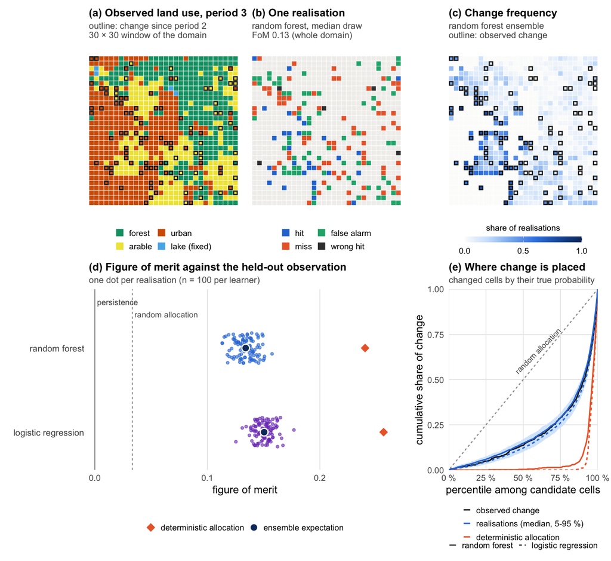

```r
col_surface <- "#f1f0ed"
# Okabe-Ito: distinguishable under the common colour-vision deficiencies
lulc_cols <- c(
  "forest" = "#009E73",
  "arable" = "#F0E442",
  "urban" = "#D55E00",
  "lake (fixed)" = "#56B4E9"
)
outcome_cols <- c(
  "persistence" = col_surface,
  "hit" = "#2a78d6",
  "miss" = "#eb6834",
  "false alarm" = "#1baf7a",
  "wrong hit" = "#3d3d3d"
)
seq_blue <- c("#fcfcfb", "#cde2fb", "#86b6ef", "#3987e5", "#1c5cab", "#0d366b")
learner_cols <- c("random forest" = "#2a78d6", "logistic regression" = "#7b3fbf")

theme_panel_text <- theme(
  plot.title = element_text(size = 9, face = "bold", hjust = 0, margin = margin(b = 3)),
  plot.subtitle = element_text(size = 7.5, colour = "#555555", margin = margin(b = 4)),
  legend.position = "bottom",
  legend.title = element_blank(),
  legend.key.size = unit(7, "pt"),
  legend.text = element_text(size = 7)
)
theme_map <- theme_void(base_size = 9) +
  theme_panel_text +
  theme(plot.margin = margin(2, 6, 2, 6))
outline <- function() {
  geom_tile(
    data = coords_xy[observed_change_cells, on = "id_coord", nomatch = NULL],
    aes(x, y),
    fill = NA,
    colour = "#1a1a1a",
    linewidth = 0.45,
    width = 70,
    height = 70,
    inherit.aes = FALSE
  )
}

p_a <- ggplot(coords_xy[panel_lulc, on = "id_coord", nomatch = NULL], aes(x, y, fill = status)) +
  geom_tile(colour = "white", linewidth = 0.15) +
  outline() +
  scale_fill_manual(values = lulc_cols, breaks = names(lulc_cols)) +
  coord_equal(expand = FALSE) +
  labs(
    title = "(a) Observed land use, period 3",
    subtitle = sprintf(
      "outline: change since period 2\n%d \u00d7 %d window of the domain",
      n_window,
      n_window
    )
  ) +
  theme_map +
  guides(fill = guide_legend(nrow = 2))

p_b <- ggplot(coords_xy[panel_draw, on = "id_coord", nomatch = NULL], aes(x, y, fill = status)) +
  geom_tile(colour = "white", linewidth = 0.15) +
  scale_fill_manual(
    values = outcome_cols,
    breaks = intersect(names(outcome_cols)[-1], unique(panel_draw$status))
  ) +
  coord_equal(expand = FALSE) +
  labs(
    title = "(b) One realisation",
    subtitle = sprintf(
      "random forest, median draw\nFoM %.2f (whole domain)",
      fom[id_run == shown_run, figure_of_merit]
    )
  ) +
  theme_map +
  guides(fill = guide_legend(nrow = 2))

p_c <- ggplot(coords_xy[panel_freq, on = "id_coord", nomatch = NULL], aes(x, y)) +
  geom_tile(aes(fill = p_change), colour = "white", linewidth = 0.15) +
  outline() +
  scale_fill_gradientn(
    colours = seq_blue,
    limits = c(0, 1),
    breaks = c(0, 0.5, 1),
    name = "share of realisations",
    guide = guide_colourbar(title.position = "top", title.hjust = 0.5)
  ) +
  coord_equal(expand = FALSE) +
  labs(
    title = "(c) Change frequency",
    subtitle = "random forest ensemble\noutline: observed change"
  ) +
  theme_map +
  theme(
    legend.title = element_text(size = 7),
    legend.key.width = unit(20, "pt"),
    legend.key.height = unit(5, "pt")
  )

# (d): one row per learner, realisations jittered within the row
row_y <- setNames(c(1, 0), learners$label)
fom[, y := row_y[label]]
fom_ensemble[, y := row_y[label]]
fom_deterministic[, y := row_y[label]]
set.seed(7)
p_d <- ggplot(fom, aes(x = figure_of_merit, y = y)) +
  geom_vline(xintercept = 0, colour = "#9a9a9a", linewidth = 0.4) +
  geom_vline(xintercept = fom_null, colour = "#9a9a9a", linewidth = 0.4, linetype = "22") +
  annotate(
    "text",
    x = 0,
    y = 1.55,
    label = " persistence",
    hjust = 0,
    size = 2.4,
    colour = "#555555"
  ) +
  annotate(
    "text",
    x = fom_null,
    y = 1.4,
    label = " random allocation",
    hjust = 0,
    size = 2.4,
    colour = "#555555"
  ) +
  geom_jitter(aes(colour = label), height = 0.18, width = 0, size = 0.9, alpha = 0.6) +
  geom_point(
    data = fom_ensemble,
    aes(shape = "ensemble expectation"),
    size = 2.6,
    fill = "#0d366b",
    colour = "white",
    stroke = 0.7
  ) +
  geom_point(
    data = fom_deterministic,
    aes(shape = "deterministic allocation"),
    size = 2.8,
    fill = "#eb6834",
    colour = "white",
    stroke = 0.7
  ) +
  scale_colour_manual(values = learner_cols, guide = "none") +
  scale_shape_manual(
    values = c("ensemble expectation" = 21, "deterministic allocation" = 23),
    name = NULL
  ) +
  scale_y_continuous(
    breaks = row_y,
    labels = names(row_y),
    limits = c(-0.45, 1.7),
    expand = c(0, 0)
  ) +
  scale_x_continuous(limits = c(0, NA), expand = expansion(mult = c(0.02, 0.06))) +
  labs(
    title = "(d) Figure of merit against the held-out observation",
    subtitle = sprintf("one dot per realisation (n = %d per learner)", n_realisations),
    x = "figure of merit",
    y = NULL
  ) +
  theme_minimal(base_size = 9) +
  theme_panel_text +
  theme(
    panel.grid.major.y = element_blank(),
    panel.grid.minor = element_blank(),
    panel.grid.major.x = element_line(colour = "#e6e6e6", linewidth = 0.3),
    axis.text.y = element_text(size = 7.5)
  )

# (e): colour = how change was placed, line type = learner
cdf_lines <- rbind(
  data.table(x = rank_grid, cdf = cdf_observed, what = "observed change", learner = "observed"),
  cdf_band[, .(x, cdf = med, what = "realisations (median, 5-95 %)", learner)],
  cdf_deterministic[, .(x, cdf, what = "deterministic allocation", learner)]
)
cdf_lines[,
  learner := factor(learner, c("observed", learners$learner), c("observed", learners$label))
]
cdf_band[, learner := factor(learner, learners$learner, learners$label)]
what_cols <- c(
  "observed change" = "#1a1a1a",
  "realisations (median, 5-95 %)" = "#2a78d6",
  "deterministic allocation" = "#eb6834"
)
p_e <- ggplot() +
  geom_abline(slope = 1, intercept = 0, colour = "#9a9a9a", linewidth = 0.4, linetype = "22") +
  annotate(
    "text",
    x = 0.6,
    y = 0.66,
    label = "random allocation",
    angle = 45,
    size = 2.3,
    colour = "#555555"
  ) +
  geom_ribbon(
    data = cdf_band,
    aes(x = x, ymin = lo, ymax = hi, group = learner),
    fill = "#cde2fb",
    alpha = 0.8
  ) +
  geom_line(data = cdf_lines, aes(x, cdf, colour = what, linetype = learner), linewidth = 0.55) +
  scale_colour_manual(values = what_cols, breaks = names(what_cols)) +
  scale_linetype_manual(
    values = c("observed" = "solid", "random forest" = "solid", "logistic regression" = "22"),
    breaks = learners$label
  ) +
  scale_x_continuous(labels = function(v) paste0(v * 100, " %"), expand = c(0, 0)) +
  scale_y_continuous(expand = c(0, 0)) +
  labs(
    title = "(e) Where change is placed",
    subtitle = "changed cells by their true probability",
    x = "percentile among candidate cells",
    y = "cumulative share of change"
  ) +
  theme_minimal(base_size = 9) +
  theme_panel_text +
  theme(
    panel.grid.minor = element_blank(),
    panel.grid.major = element_line(colour = "#e6e6e6", linewidth = 0.3),
    legend.box = "vertical",
    legend.spacing.y = unit(0, "pt"),
    legend.margin = margin(0, 0, 0, 0)
  ) +
  guides(
    colour = guide_legend(order = 1, ncol = 1),
    linetype = guide_legend(order = 2, nrow = 1, override.aes = list(colour = "#555555"))
  )

fig2 <- p_a +
  p_b +
  p_c +
  p_d +
  p_e +
  plot_layout(design = "ABC\nDDE", heights = c(1, 1.05))
ggsave(
  file.path(out_dir, "fig2-ensembles.pdf"),
  fig2,
  width = 7.2,
  height = 6.6
  # device = cairo_pdf
)
fig2
```